# QC_seurat_cut_filtrado

Barrientos-González Diana, Cervantes-Levario Román & Contreras-Rivera Jair

09-06-2026

## CARGAMOS LOS DATOS FILTRADOS

```r
setwd("/mnt/data/bioinfo3/dbarrientos/proyecto_integrador/scripts")

seurat_cut_filtrado <- readRDS("seurat_cut_filtrado.rds")
```

```r
set.seed(123)
```

## EXPLORAMOS EL ARCHIVO

```r
dim(seurat_cut_filtrado)                     # genes x células
```

```
[1] 38606    44
```

```r
Assays(seurat_cut_filtrado)                  # indica qué tipo de datos moleculares vienen en el objeto (RNA en este caso)
```

```
[1] "RNA"
```

```r
Layers(seurat_cut_filtrado[["RNA"]])         # por ahora la única capa es counts, pero después de normalizar y escalar será: counts, data, scale.data
```

```
[1] "counts"
```

```r
Reductions(seurat_cut_filtrado)              # pca, umap, tsne si existen (aún no se hace --> NULL)
```

```r
colnames(seurat_cut_filtrado@meta.data)      # todas las columnas de metadatos
```

```
[1] "orig.ident"   "nCount_RNA"   "nFeature_RNA"
```

orig.ident: origen de la muestra a la que pertenece la célula nCount_RNA: número de RNAs detectados en esa célula nFeature_RNA: número de genes distintos (no moléculas) detectados en cada célula

```r
str(seurat_cut_filtrado, max.level = 2)      # estructura completa
```

```
Formal class 'Seurat' [package "SeuratObject"] with 13 slots
  ..@ assays      :List of 1
  ..@ meta.data   :'data.frame':    44 obs. of  3 variables:
  ..@ active.assay: chr "RNA"
  ..@ active.ident: Factor w/ 1 level "cut_filtrado": 1 1 1 1 1 1 1 1 1 1 ...
  .. ..- attr(*, "names")= chr [1:44] "AAACCCAAGGTAGTAT-1" "AAACCCAAGTAAGAGG-1" "AAACCCACATTCAGGT-1" "AAACGAACAGAAGCTG-1" ...
  ..@ graphs      : list()
  ..@ neighbors   : list()
  ..@ reductions  : list()
  ..@ images      : list()
  ..@ project.name: chr "cut_filtrado"
  ..@ misc        : list()
  ..@ version     :Classes 'package_version', 'numeric_version'  hidden list of 1
  ..@ commands    : list()
  ..@ tools       : list()
```

```r
summary(seurat_cut_filtrado$nCount_RNA)      # distribución de una métrica: distribución de los conteos de RNA
```

```
   Min. 1st Qu.  Median    Mean 3rd Qu.    Max.
   1906    3683    4386    5850    7785   18483
```

```r
table(seurat_cut_filtrado$orig.ident)        # células por muestra
```

```
cut_filtrado
          44
```

```r
head(rownames(seurat_cut_filtrado))          # nombres de genes, hay tanto símbolos de genes como identificadores ENSG
```

```
[1] "DDX11L2"         "MIR1302-2HG"     "FAM138A"         "ENSG00000290826" "OR4F5"
[6] "ENSG00000238009"
```

## CARGAMOS LOS GENES MITOCONDRIALES PARA CALCULAR EL PORCENTAJE DE RNA MITOCONDRIAL, CONTAMINACIÓN

Primero seurat_cut_filtrado muestra el porcentaje de conteos de RNA que provienen de genes mitocondriales nFeature: genes detectados por célula nCount: cuánto RNA se detecta en cada célula percent.mt: proporción que corresponde a mitocondrial percent.ribo: proporción que corresponde a RNA ribosomal

Para descartar contaminación por ARN ambiental, revisamos la expresión de genes marcadores que no corresponden a PBMC o que se esperan en tipos celulares muy específicos (HBB, HBA1, PPBP, IGKC y S100A8): HBB y HBA1 no se detectaron en ninguna célula, y PPBP, IGKC y S100A8 aparecieron solo en unas pocas con valores altos, lo que sugiere expresión propia de esas células (plaquetas pegadas, linfocitos B o monocitos) y no un fondo uniforme de ARN ambiental.Esto en el fondo ya lo sabíamos por lo pequeño que es nuestro dataset por eso ningún control ambiental como SOupex fue realizado con anterioridad pero si en este paso hubiermaos encontrado lo contrario, nuestra metodología habría que ampliarse con ese paso extra.

[figure not shown]

```r
library(ggplot2)
seurat_cut_filtrado[["percent.mt"]] <- PercentageFeatureSet(seurat_cut_filtrado, pattern = "^MT-")
seurat_cut_filtrado[["percent.ribo"]] <- PercentageFeatureSet(seurat_cut_filtrado, pattern = "^RP[SL]")

figure_a = VlnPlot(seurat_cut_filtrado,
        features = c("nFeature_RNA", "nCount_RNA", "percent.mt", "percent.ribo"),
        ncol = 4, col = "pink")
# ¿aparecen genes de otros tipos en todas partes?
figure_a1  = VlnPlot(seurat_cut_filtrado, features = c("HBB", "HBA1", "PPBP", "IGKC", "S100A8"), pt.size = 0.5)

figure_a
```

```r
figure_a1
ggsave(filename = "../figures/figure_a.jpg",
       plot = figure_a,
       height = 7, width = 12,
       quality = 50)
```

[figure not shown]

```r
ggsave(filename = "../figures/figure_a1.jpg",
       plot = figure_a1,
       height = 7, width = 12,
       quality = 50)
```

Ahora observamos: nCount_RNA contra percent.mt. Las células con más RNA tienen también más porcentaje mitocondrial? (primer gráfico abajo)

También analizamos si las células que tienen más RNAs, tienes también más genes (segundo gráfico):

nCount_RNA contra percernt.ribo. Las células con más RNA tienen también más porcentaje de RNA ribosomal?

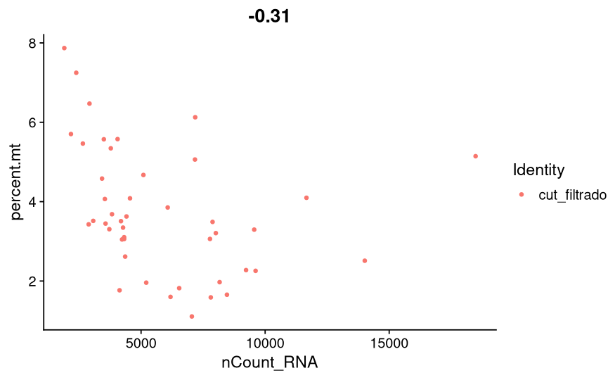

```r
# FeatureScatter se usa para visualizar relaciones entre características pero puede usar para cualquier elemento calculado
# por el objeto como columnas de metadatos y PC scores

figure_b <- FeatureScatter(seurat_cut_filtrado, feature1 = "nCount_RNA", feature2 = "percent.mt")
figure_c <- FeatureScatter(seurat_cut_filtrado, feature1 = "nCount_RNA", feature2 = "nFeature_RNA")
figure_d <- FeatureScatter(seurat_cut_filtrado, feature1 = "nCount_RNA", feature2 = "percent.ribo")
figure_b
```

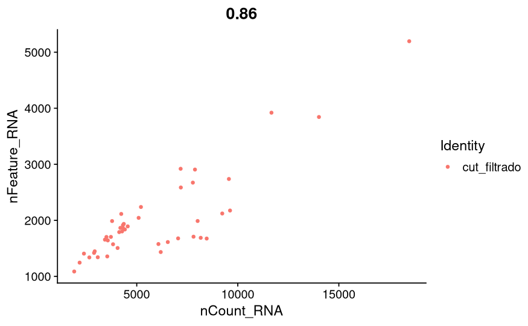

```r
figure_c
```

```r
figure_d

ggsave(filename = "../figures/figure_b.jpg",
       plot = figure_b,
       height = 7, width = 12,
       quality = 50)
```

[figure not shown]

```r
ggsave(filename = "../figures/figure_c.jpg",
       plot = figure_c,
       height = 7, width = 12,
       quality = 50)
ggsave(filename = "../figures/figure_d.jpg",
       plot = figure_d,
       height = 7, width = 12,
       quality = 50)
```

## FILTRADO QC

- Filtramos células con unique filter count mayor a 2,500 o menor a 200:
- Filtramos células con >5% counts mitocondriales:
- El filtro por percent.ribo no es estándar como el de mt po rlo cual no lo incluimos

```r
seurat_cut_filtrado <- subset(seurat_cut_filtrado, subset = nFeature_RNA > 200 & nFeature_RNA < 2500 & percent.mt < 5)
```

## NORMALIZACIÓN DEL DATA

Después de remover las células no deseadas del dataset, el siguiente paso es normalizar nuestros datos con LogNormalize que normaliza las mediciones de expresión de características para cada célula mediante la expresión total, multiplica este valor por un factor de escala (10.000 por defecto) y aplica una transformación logarítmica al resultado. En Seurat v5, los valores normalizados se almacenan en seurat_cut_filtrado[[“RNA”]]$data.

```r
seurat_cut_filtrado <- NormalizeData(seurat_cut_filtrado, normalization.method = "LogNormalize", scale.factor = 10000)
```

```r
seurat_cut_filtrado <- NormalizeData(seurat_cut_filtrado)
```

## Identificación de características altamente variables (selección de características)

A continuación, calculamos un subconjunto de características que presentan una elevada variación entre células en el conjunto de datos (es decir, que se expresan en niveles altos en algunas células y en niveles bajos en otras).

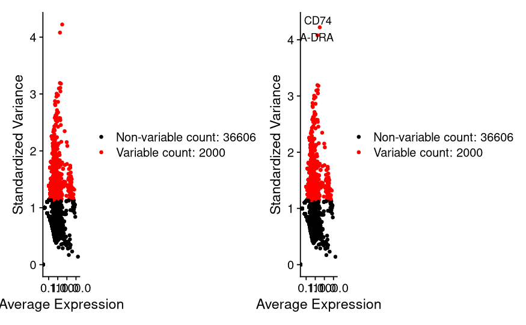

```r
seurat_cut_filtrado <- FindVariableFeatures(seurat_cut_filtrado, selection.method = "vst", nfeatures = 2000)
# Identificar los 10 genes más variables
top10 <- head(VariableFeatures(seurat_cut_filtrado), 10)

# graficar los variable features con y sin labels
figure_e <- VariableFeaturePlot(seurat_cut_filtrado)
figure_f <- LabelPoints(plot = figure_e, points = top10, repel = TRUE)
figure_ef = figure_e + figure_f

figure_ef
ggsave(filename = "../figures/figure_ef.jpg",
       plot = figure_ef,
       height = 7, width = 12,
       quality = 50)
```

En esta gráfica, cada punto es un gen y los que se destacan son aquellos que presentan alta variablidad entre células. CD74 y HLA-DRA son genes de presentación de antígeno que se expresan en linfocitos B y dendríticas, pero no en los T. Esto indica que ya hay cierta separación.

## ESCALAR AL DATA

Paso previo a reducción de dimensiones y análisis posteriores

```r
all.genes <- rownames(seurat_cut_filtrado)
seurat_cut_filtrado <- ScaleData(seurat_cut_filtrado, features = all.genes)
```

**Removamos variación que no queremos, mt para que mitocondrial no se convierta en un cluster artificial**

```r
seurat_cut_filtrado <- ScaleData(seurat_cut_filtrado, vars.to.regress = "percent.mt")
```

## Realizar una reducción dimensional lineal.

```r
ncol(seurat_cut_filtrado)                    # células. Confirmamos cuántas quedaron tras el filtrado
```

```
[1] 28
```

```r
length(VariableFeatures(seurat_cut_filtrado)) # genes variables (si da 0, falta FindVariableFeatures)
```

```
[1] 2000
```

Ahora sí, correr el PCA:

```r
seurat_cut_filtrado <- RunPCA(seurat_cut_filtrado,
                              features = VariableFeatures(seurat_cut_filtrado),
                              npcs = 15) #tengo menos de 50 que es el default de la funcion
```

```r
# Examine and visualize PCA results a few different ways
print(seurat_cut_filtrado[["pca"]], dims = 1:5, nfeatures = 5)
```

```
PC_ 1
Positive:  RPS25, RPL5, RPS4X, RPL32, RPS15
Negative:  MICAL2, RBM47, FCN1, ENSG00000257764, SLC11A1
PC_ 2
Positive:  BCL11A, KHDRBS2, BANK1, HLA-DRB1, ADAM28
Negative:  TC2N, SORL1, PRKCQ, LEF1, CD247
PC_ 3
Positive:  RPS13, RPL35A, RPS3A, RPL36AL, SCFD1
Negative:  AQR, SCLT1, OPTN, GCH1, KANSL1L
PC_ 4
Positive:  MIR646HG, ARHGAP32, PCID2, OTUD7B, PCCA
Negative:  GSK3B-DT, TRPC1, CDK11B, ZYG11B, ENSG00000288075
PC_ 5
Positive:  ATP5MC1, GLB1, LSM12, GRK2, SLC25A19
Negative:  BPTF, VSIR, ADIPOR2, LY96, JAZF1
```

Buscando en The Human Protein Atlas: los que aparecen positivos de PC1 son genes ribosomales, mientras que en el negativo encontramos genes expresados principalmente en monocitos.

PC2: los positivos son genes que se expresan principalmente en células dendríticas y linfocitos B. Mientras que los del polo negativo son característicos de T-cells. Esto indica una separación que puede ser interesante para los T-cells.

PC3: el positivo muestra otro grupo de genes ribosomales, mientras que el negativo muestra factores de splicing, autofagia y metabolismo de pterinas.

PC3, PC4 y PC5 contienen genes que no necesariamente se encuentran expresados en un único tipo celular, sino que son importantes en procesos como ciclo celular y metabolismo.

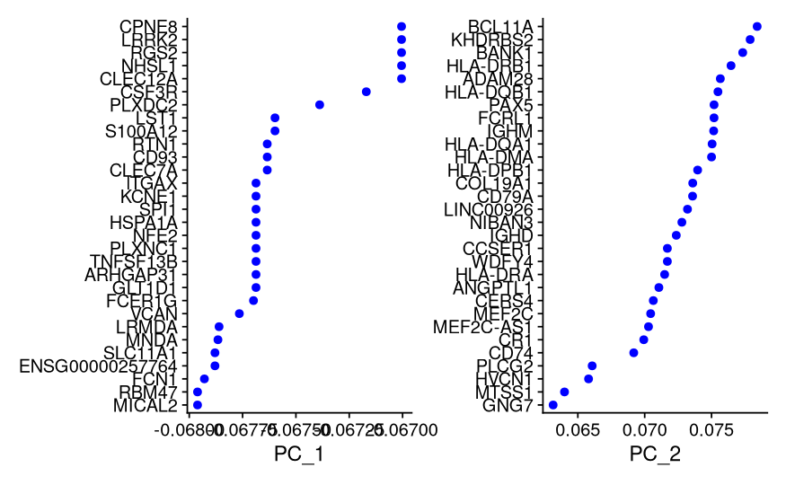

```r
figure_g = VizDimLoadings(seurat_cut_filtrado, dims = 1:2, reduction = "pca")
figure_g
ggsave(filename = "../figures/figure_g.jpg",
       plot = figure_g,
       height = 7, width = 12,
       quality = 50)
```

En esta gráfica vemos los genes que más contribuyen para PC1 y PC2

Esto indica que PC1 está capturando variabilidad relacionada con células de inmunidad innata (neutrófilos y macrófagos). Por otro lado, PC2 refleja actividad de inmunidad adaptativa y presentación de antígenos. Hay varios genes relacionados con el complejo mayor de histocompatibilidad y expresados en células B.

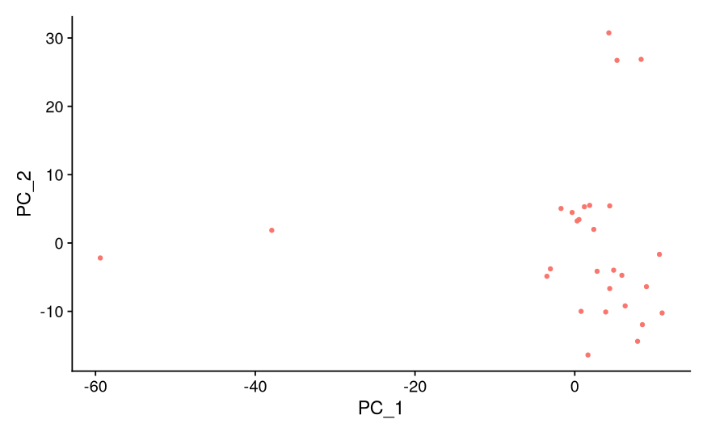

```r
figure_h = DimPlot(seurat_cut_filtrado, reduction = "pca") + NoLegend()
figure_h
ggsave(filename = "../figures/figure_h.jpg",
       plot = figure_h,
       height = 7, width = 12,
       quality = 50)
```

Indica células con una expresión parecida.

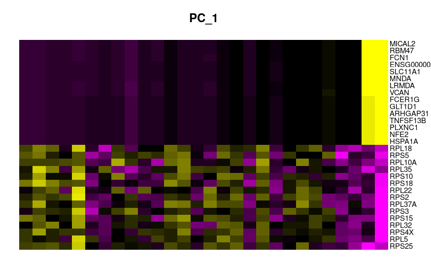

```r
figure_i = DimHeatmap(seurat_cut_filtrado, dims = 1, cells = 500, balanced = TRUE)
```

```r
figure_i
```

```r
ggsave(filename = "../figures/figure_i.jpg",
       plot = figure_i,
       height = 7, width = 12,
       quality = 50)
```

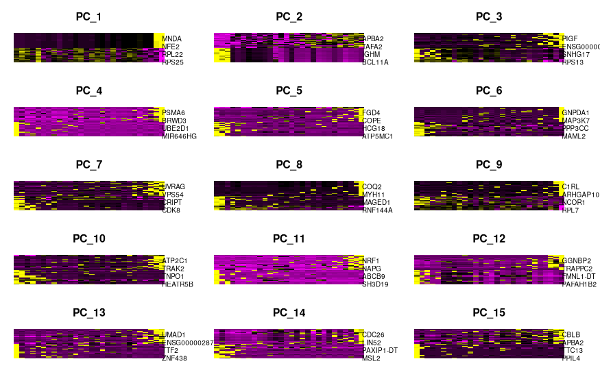

```r
figure_j = DimHeatmap(seurat_cut_filtrado, dims = 1:15, cells = 500, balanced = TRUE)
```

```r
figure_j
```

```r
ggsave(filename = "../figures/figure_j.jpg",
       plot = figure_j,
       height = 7, width = 12,
       quality = 50)
```

Aunque estas gráficas muestran más genes, sí podemos ver por ejemplo en PC2 lo que se mencionó previamente, que separa los linfocitos B de otros tipos celulares (porque aparecen genes específicos de este tipo celular y se observa un bloque separado, del lado izquierdo. Podemos ver cómo con mayor número de PCs,decae la señal y se dificulta distinguir grupos, a partir de 5 o 6 componentes.

# Determinar la dimensionalidad del conjunto de datos

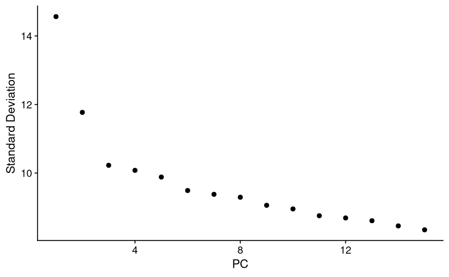

```r
figure_k = ElbowPlot(seurat_cut_filtrado)
figure_k
ggsave(filename = "../figures/figure_k.jpg",
       plot = figure_k,
       height = 7, width = 12,
       quality = 50)
```

## Cluster de células

```r
seurat_cut_filtrado <- FindNeighbors(seurat_cut_filtrado, dims = 1:10, k.param = 5)#subimos k.param para que encuentre clusters con datos muy chicos
seurat_cut_filtrado <- FindClusters(seurat_cut_filtrado, resolution = 1.5) #generalmente resolution está entre 0.8 y 1.5. más alto es para forzar clusters en pocas células
```

```
Modularity Optimizer version 1.3.0 by Ludo Waltman and Nees Jan van Eck

Number of nodes: 28
Number of edges: 233

Running Louvain algorithm...
```

```
Maximum modularity in 10 random starts: 0.1738
Number of communities: 5
Elapsed time: 0 seconds
```

```r
#Ver los IDs de cluster de las primeras 5 células:
head(Idents(seurat_cut_filtrado), 5)
```

```
AAACCCAAGGTAGTAT-1 AAACCCAAGTAAGAGG-1 AAACGAATCATATGGC-1 AAACGCTCACGCAGTC-1 AAACGCTGTTAGGCTT-1
                 2                  4                  1                  0                  2
Levels: 0 1 2 3 4
```

## Ejecutar reducción de dimensionalidad no lineal (UMAP)

```r
seurat_cut_filtrado <- RunUMAP(seurat_cut_filtrado, dims = 1:10,  n.neighbors = 3) #vecinos por default es 30 y tenemos menos células, 28, así que ponemos 3
```

```
Using method 'umap'
```

**NOTA: SE ESCOGIÓ EL UMAP QUE SE VIERA ESTÉTICAMENTE MEJOR, PERO ESTO NO TIENE BUENA INTERPRETACIÓN BIOLÓGICA POR EL SUBSET PEQUEÑO**

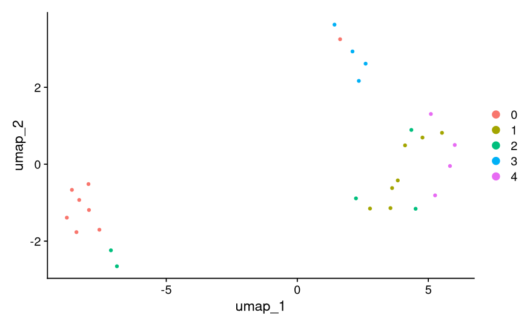

```r
figure_l = DimPlot(seurat_cut_filtrado, reduction = "umap")
figure_l
ggsave(filename = "../figures/figure_l.jpg",
       plot = figure_l,
       height = 7, width = 12,
       quality = 50)
```

La gráfica muestra un grupo muy separado a la izquierda, con células del cluster 0 y 2 También se observa un grupo con células del grupo 3 y 0 arriba, que coincide con células B. Por último, hay una mezcla de tres clusters: 1, 4 y 2.

Observamos que el cluster 2 está partido en dos regiones, lo cual indicaría que son grupos de células heterogéneas.

Sin embargo, este análisis es complicado debido al escaso número de células, por lo cual estas separaciones no son confiables.